[output not shown]

# Question

Valentina y José viven en un hogar y comparten el pago de los gastos. En agosto consumieron 12 metros cúbicos de gas natural y la factura fue de $16.600, incluido el cargo fijo de $2.800 que es el mismo todos los meses. La gráfica muestra el consumo histórico en metros cúbicos de ese servicio.

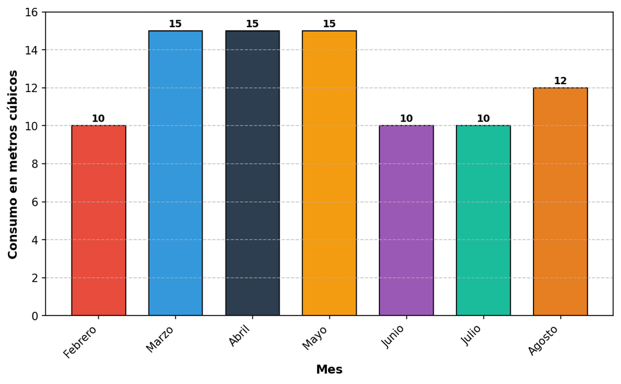

Un hogar puede consumir máximo 25 metros cúbicos en un mes. Para determinar qué porcentaje del consumo máximo posible corresponde al consumo de abril, resuelva paso a paso:

### Paso 1: Lectura del gráfico

Observe cuidadosamente la gráfica de barras. ¿Cuántos metros cúbicos de gas natural se consumieron en abril?

**Respuesta:** ##ANSWER1## metros cúbicos

### Paso 2: Identificación del consumo máximo

Según el enunciado del problema, ¿cuál es el consumo máximo posible que puede tener un hogar en un mes?

**Respuesta:** ##ANSWER2## metros cúbicos

### Paso 3: Configuración de la fórmula de porcentaje

Para calcular el porcentaje, complete la fórmula con los valores identificados:

Porcentaje = ( ##ANSWER3## ÷ ##ANSWER4## ) × 100%

### Paso 4: Cálculo de la división

Calcule el resultado de la división anterior (exprese su respuesta con 4 decimales):

##ANSWER3## ÷ ##ANSWER4## = ##ANSWER5##

### Paso 5: Resultado final

Multiplique el resultado anterior por 100 para obtener el porcentaje final:

##ANSWER5## × 100 = ##ANSWER6##%

### Paso 6: Confirmación mediante selección múltiple (CON PUNTUACIÓN)

Ahora que ha completado el análisis paso a paso, **confirme su respuesta seleccionando la opción correcta**. Esta selección también será evaluada y contribuirá a su puntuación final.

**Pregunta:** Basándose en su análisis anterior, ¿a qué porcentaje del consumo máximo posible corresponde el consumo de abril?

##ANSWER7##

**Conclusión:** El consumo de abril representa el ##ANSWER6##% del consumo máximo posible.

# Solution

### Análisis paso a paso del problema

Este problema de **interpretación de gráficos de barras** y **cálculo de porcentajes** requiere un análisis secuencial que demuestre el proceso de razonamiento matemático:

### Paso 1: Lectura correcta de la gráfica ✓

**Consumos mensuales registrados:**

- Febrero: 10 metros cúbicos
- Marzo: 15 metros cúbicos
- Abril: 15 metros cúbicos ← **MES DE LA PREGUNTA**
- Mayo: 15 metros cúbicos
- Junio: 10 metros cúbicos
- Julio: 10 metros cúbicos
- Agosto: 12 metros cúbicos ← **MES DE LA FACTURA**

**Respuesta correcta:** 15 metros cúbicos

La lectura cuidadosa del gráfico de barras muestra que en abril se consumieron exactamente 15 metros cúbicos de gas natural.

### Paso 2: Identificación del consumo máximo ✓

**Respuesta correcta:** 25 metros cúbicos

El enunciado establece claramente que “un hogar puede consumir máximo 25 metros cúbicos en un mes”.

### Paso 3: Configuración correcta de la fórmula ✓

**Respuestas correctas:** Numerador = 15, Denominador = 25

La fórmula de porcentaje requiere:

- **Numerador:** El valor observado (15 metros cúbicos)
- **Denominador:** El valor máximo posible (25 metros cúbicos)

### Paso 4: Cálculo preciso de la división ✓

**Respuesta correcta:** 0.6

$$\frac{15}{25} = 0.6$$

### Paso 5: Conversión a porcentaje ✓

**Respuesta correcta:** 60%

$$0.6 \times 100 = 60\%$$

### Paso 6: Confirmación mediante selección múltiple ✓ (CON PUNTUACIÓN)

**Opciones presentadas:**

- **A**: 60% ← **RESPUESTA CORRECTA**
- **B**: 40%
- **C**: 15%
- **D**: 65%

**Importancia de este paso:**

- **Contribuye a la puntuación final** (no es solo verificación)
- **Confirma** la comprensión del proceso analítico completo
- **Identifica** posibles errores en el razonamiento matemático
- **Refuerza** el aprendizaje mediante comparación con distractores educativos

### Verificación del proceso de razonamiento híbrido completo

**Resultado final:** 60%

**El formato híbrido con puntuación dual (cloze + schoice) garantiza que los estudiantes:**

**Parte Analítica (Pasos 1-5):**

- **Lean cuidadosamente** el gráfico para extraer datos precisos
- **Identifiquen explícitamente** el consumo máximo del enunciado
- **Configuren correctamente** la fórmula de porcentaje paso a paso
- **Realicen cálculos** matemáticos sin saltar etapas del proceso

**Parte de Confirmación (Paso 6):**

- **Demuestren coherencia** entre su análisis y la respuesta final
- **Apliquen pensamiento crítico** al comparar con distractores
- **Consoliden su aprendizaje** mediante validación de resultados

### Conclusión

El consumo de abril (15 metros cúbicos) representa el **60%** del consumo máximo posible (25 metros cúbicos).

Esta respuesta es coherente porque:

- Se basa en una lectura correcta de la gráfica
- Aplica correctamente la fórmula de porcentaje
- El resultado está dentro del rango esperado (0% a 100%)

**Verificación adicional**: La factura de agosto ($16.600) corresponde exactamente al consumo mostrado en la gráfica (12 m³ × $1.150 + $2.800 cargo fijo).

# Meta-information

exname: Consumo Gas Natural Porcentaje Máximo - Análisis Secuencial extype: cloze exsolution: 15|25|15|25|0.6|60|1 exclozetype: num|num|num|num|num|num|schoice extol: 0|0|0|0|0.0001|0|0 exsection: Estadística|Interpretación de gráficos|Porcentajes|Análisis de datos exextra[Type]: Cálculo exextra[Program]: R exextra[Language]: es exextra[Level]: 2 exextra[Competencia]: Interpretación y representación exextra[Componente]: Aleatorio y sistemas de datos exextra[Contexto]: Familiar exextra[Dificultad]: Media